# Regression discontinuity design (RDD)

```
Rows: 6,558
Columns: 2
$ x <dbl> 0.1049, 0.1393, -0.0736, 0.0868, 0.3994, 0.1681, 0.2516, 0…
$ y <dbl> 0.5810, 0.4611, 0.5434, 0.5846, 0.5803, 0.6244, 0.4873, 0.…
```

[output not shown]

## Exercises

### Opg 1)

> Suppose we’re interested in the effects of the generosity of public assistance on labor supply. Historically, U.S. states have offered widely-varying wel- fare payments to poor unmarried mothers. Labor economists have long been interested in the effects of such income maintenance policies - how much of an increase in living standards they facilitate, and whether they make work less attractive. Could there be any potential problems us- ing a DiD approach to look at this question? (Hint: people can move…) How about the example we covered in class looking at the employment of teenagers?
- Hvis en stat indføre bedre vilkår så vil de måske flytte også vil vi violate antagelse om paralelle trend.

### Opg 2)

> Use the data in ’eitc.dta’ for this question (you’ll have to use the function read.dta(), in the ’foreign’ library, to get it into R). The Earned Income Tax Credit (EITC) is a refundable tax credit for low income working in- dividuals, particularly those with children. A major change to the EITC occurred in 1993. In his first State of the Union Address, President Clinton said, “The new direction I propose will make this solemn, simple commit- ment: By expanding the refundable earned income tax credit, we will make history; we will reward the work of millions of working poor Amer- icans by realizing the principle that if you work forty hours a week and you’ve got a child in the house, you will no longer be in poverty.” The main result of this change was that single, working, women with children get more money from the government. The dataset contains information on single US women around the time of the expansion of EITC.

```
Rows: 13,746
Columns: 11
$ state    <dbl> 11, 12, 13, 14, 15, 16, 21, 22, 23, 31, 32, 33, 34,…
$ year     <dbl> 1991, 1991, 1991, 1991, 1991, 1991, 1991, 1991, 199…
$ urate    <dbl> 7.6, 7.2, 6.4, 9.1, 8.6, 6.8, 7.3, 6.7, 7.0, 6.4, 6…
$ children <int> 0, 1, 2, 0, 3, 1, 0, 0, 1, 2, 0, 2, 0, 0, 0, 1, 1, …
$ nonwhite <int> 1, 0, 0, 1, 1, 0, 1, 1, 1, 1, 0, 0, 0, 0, 1, 0, 0, …
$ finc     <dbl> 18714.394, 4838.568, 8178.194, 9369.570, 14706.608,…
$ earn     <dbl> 18714.3943, 471.3656, 0.0000, 0.0000, 14706.6079, 1…
$ age      <int> 26, 22, 33, 43, 23, 53, 52, 51, 20, 32, 51, 29, 54,…
$ ed       <int> 10, 9, 11, 11, 7, 7, 11, 11, 11, 11, 9, 10, 9, 11, …
$ work     <int> 1, 1, 0, 0, 1, 1, 1, 1, 1, 1, 1, 1, 0, 0, 0, 0, 0, …
$ unearn   <dbl> 0.0000000, 4.3672026, 8.1781938, 9.3695705, 0.00000…
```

#### i)

> Create a dummy variable to indicate post-treatment (assume that 1993 counts as pre-treatment). Also create a dummy variable to indi- cate whether a woman was ’treated’.

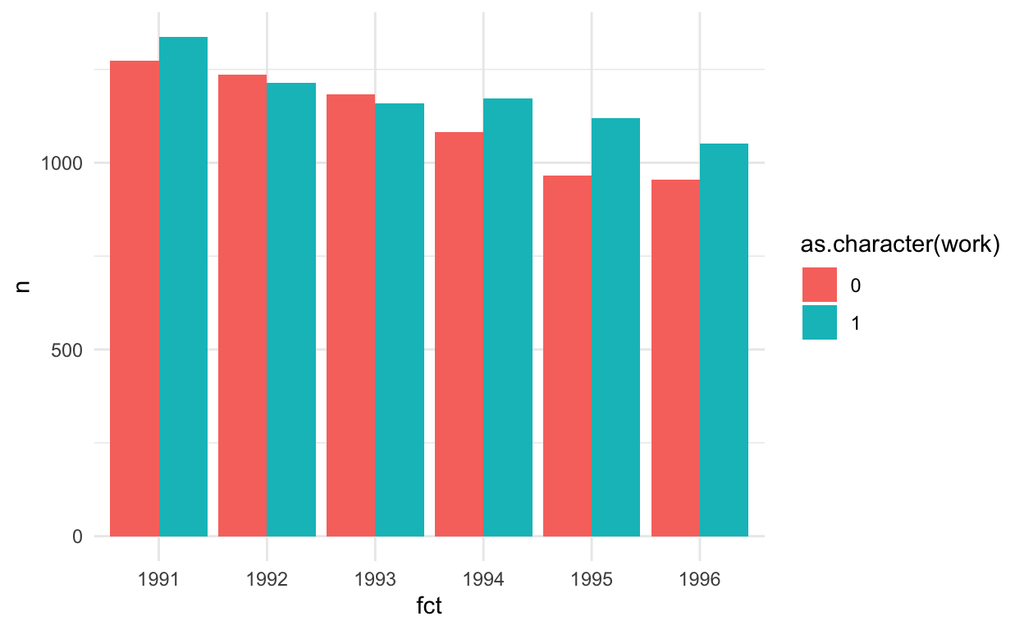

```
# A tibble: 3 × 12
  fct   state  year urate children nonwhite   finc   earn   age    ed
  <chr> <dbl> <dbl> <dbl>    <dbl>    <dbl>  <dbl>  <dbl> <dbl> <dbl>
1 1991   54.0  1991  7.03     1.21    0.571 15304. 10498.  35.1  8.76
2 1992   53.7  1992  7.80     1.21    0.575 14929.  9938.  35.0  8.77
3 1993   53.0  1993  7.23     1.19    0.592 14382.  9520.  35.1  8.85
# … with 2 more variables: work <dbl>, unearn <dbl>
```

```
# A tibble: 3 × 12
  fct   state  year urate children nonwhite   finc   earn   age    ed
  <chr> <dbl> <dbl> <dbl>    <dbl>    <dbl>  <dbl>  <dbl> <dbl> <dbl>
1 1994   53.9  1994  6.48     1.18    0.622 15312. 10359.  35.5  8.86
2 1995   56.4  1995  5.96     1.19    0.632 15893. 11246.  35.1  8.78
3 1996   56.7  1996  5.76     1.16    0.623 15884. 11253.  35.6  8.84
# … with 2 more variables: work <dbl>, unearn <dbl>
```

```
Rows: 13,746
Columns: 13
$ state    <dbl> 11, 12, 13, 14, 15, 16, 21, 22, 23, 31, 32, 33, 34,…
$ year     <dbl> 1991, 1991, 1991, 1991, 1991, 1991, 1991, 1991, 199…
$ urate    <dbl> 7.6, 7.2, 6.4, 9.1, 8.6, 6.8, 7.3, 6.7, 7.0, 6.4, 6…
$ children <int> 0, 1, 2, 0, 3, 1, 0, 0, 1, 2, 0, 2, 0, 0, 0, 1, 1, …
$ nonwhite <int> 1, 0, 0, 1, 1, 0, 1, 1, 1, 1, 0, 0, 0, 0, 1, 0, 0, …
$ finc     <dbl> 18714.394, 4838.568, 8178.194, 9369.570, 14706.608,…
$ earn     <dbl> 18714.3943, 471.3656, 0.0000, 0.0000, 14706.6079, 1…
$ age      <int> 26, 22, 33, 43, 23, 53, 52, 51, 20, 32, 51, 29, 54,…
$ ed       <int> 10, 9, 11, 11, 7, 7, 11, 11, 11, 11, 9, 10, 9, 11, …
$ work     <int> 1, 1, 0, 0, 1, 1, 1, 1, 1, 1, 1, 1, 0, 0, 0, 0, 0, …
$ unearn   <dbl> 0.0000000, 4.3672026, 8.1781938, 9.3695705, 0.00000…
$ time     <dbl> 0, 0, 0, 0, 0, 0, 0, 0, 0, 0, 0, 0, 0, 0, 0, 0, 0, …
$ treated  <dbl> 1, 1, 0, 0, 1, 1, 1, 1, 1, 1, 1, 1, 0, 0, 0, 0, 0, …
```

#### ii)

> Compute the four averages that you need in order to calculate the DiD estimate of whether the expansion of EITC has lead single mothers to work more. What is the estimate, how do you interpret it, and is this what you expected? Can you say anything about its statistical significance at this point?

#### iii)

> Answer the same question as part (ii) but this time, use a regres- sion approach. Has this given you any more information?

```
Call:
lm(formula = work ~ time + treated + time:treated, data = df)

Residuals:
                Min                  1Q              Median
-0.0000000000096609  0.0000000000000000  0.0000000000000000
                 3Q                 Max
 0.0000000000000026  0.0000000000000799

Coefficients:
                          Estimate            Std. Error
(Intercept)  -0.000000000000084034  0.000000000000001357
time         -0.000000000000002940  0.000000000000002026
treated       1.000000000000167644  0.000000000000001916
time:treated -0.000000000000002603  0.000000000000002823
                         t value            Pr(>|t|)
(Intercept)              -61.945 <0.0000000000000002 ***
time                      -1.452               0.147
treated      521840361343354.625 <0.0000000000000002 ***
time:treated              -0.922               0.356
---
Signif. codes:  0 '***' 0.001 '**' 0.01 '*' 0.05 '.' 0.1 ' ' 1

Residual standard error: 0.00000000000008243 on 13742 degrees of freedom
Multiple R-squared:      1, Adjusted R-squared:      1
F-statistic: 1.685e+29 on 3 and 13742 DF,  p-value: < 0.00000000000000022
```

#### iv) Include the following controls into your regression from part (iii): nonwhite, age, ed (where ed denotes education). What do you notice? What do you conclude about the causal interpretation from part (iii)?

#### v)

> Finally, to the regression in part (iv), add unearned income to your regression, unearn (this is income that you get from anything other than working). Now what happens? Why?